# Introduction

Tunisair se trouve aujourd’hui investi d’un éventail très large de missions revêtant un caractère stratégique, dans la mesure où elles conditionnent le développement du transport aérien dans notre pays, ainsi que les secteurs économiques qui lui sont liés.

En effet, Tunisair constitue un maillon important de l’infrastructure des transports nationaux et internationaux , elle se positionne en tant qu’acteur de développement économique et social des régions qu’ils desservent.

# Compréhension Métier

## Objectifs :

-Assurer le bon fonctionnement d’un réseau de transport aérien régulier et charter

-Contribuer au développement du tourisme qui constitue une des sources principales du revenu national

-Planifier le développement des infrastructures aéroportuaires et augmenter leur capacité pour satisfaire une demande future et créer les conditions d’une attractivité plus forte

-Se positionner avantageusement au service des clients aériens en leur offrant un service de qualité avec tous les conditions requises de sécurité et dans le respect total de l’environnement Fin de la discussion

## Data science goals:

-Dégager la standardisation qui peut favoriser la concurrence sur une echelle mondiale.

-Dégager les caractéristiques des avions qui peuvent améliorer les services selon la destination aérienne(l’enjeu touristique)

# Compréhension des données:

## 1- Collecte des données:

aircrafts.csv : https://www.seatguru.com/charts/shorthaul_economy.php

```python
import pandas as pd
import numpy as np
from bs4 import BeautifulSoup

fname = r"airlineWebPage.html"
HtmlFile = open(fname, 'r', encoding='utf-8')
source_code = HtmlFile.read()
from bs4 import BeautifulSoup
soup = BeautifulSoup(source_code, 'html.parser')

table = soup.find('tbody')
rows = table.find_all('tr')

Airline = []
AircraftWithSeatmap = []
SeatPitch = []
SeatWidth = []
VideoType = []
LaptopPower = []
PowerType = []
WiFi = []
SeatType = []
rows
for tr in rows:
    cols = tr.find_all('td')

    Airline.append(cols[0].text.strip())
    AircraftWithSeatmap.append(cols[1].text.strip())
    SeatPitch.append(cols[2].text.strip())
    SeatWidth.append(cols[3].text.strip())
    VideoType.append(cols[4].text.strip())
    LaptopPower.append(cols[5].text.strip())
    PowerType.append(cols[6].text.strip())
    WiFi.append(cols[7].text.strip())
    SeatType.append(cols[8].text.strip())





FileTableOfAirLines = pd.DataFrame(data={'Airline':Airline,'Constructor':AircraftWithSeatmap,
                        'AircraftType':SeatPitch,'SeatWidth':SeatWidth,'VideoType':VideoType,
                        'laptopPower':LaptopPower,'PowerType':PowerType,'Wifi':WiFi,'SeatType':SeatType
                         })

FileTableOfAirLines=FileTableOfAirLines[['Airline','Constructor', 'AircraftType', 'SeatWidth','VideoType',
                                        'laptopPower','PowerType','Wifi','SeatType']]

FileTableOfAirLines
```

|  | Airline | Constructor | AircraftType | SeatWidth | VideoType | laptopPower | PowerType | Wifi | SeatType |
| --- | --- | --- | --- | --- | --- | --- | --- | --- | --- |
| 0 | Aegean Airlines | Airbus A319 (319) | 30 | 18 | None | None | None | No | Standard |
| 1 | Aegean Airlines | Airbus A320 (320) | 30 | 18 | Overhead TV | None | None | No | Standard |
| 2 | Aegean Airlines | ATR 42-600 (ATR) | 30 | 17 | None | None | None | No | Standard |
| 3 | Aegean Airlines | Bombardier Q400 (DH4) | 30 | 17 | None | None | None | No | Standard |
| 4 | Aer Lingus | Airbus A320 (320) | 31-32 | 17 | None | None | None | No | Standard |
| 5 | Aer Lingus | Airbus A321 (321) | 31-32 | 17 | None | None | None | No | Standard |
| 6 | Aeroflot | Airbus A320 (320) V1 | 30-32 | 18 | None | None | None | No | Standard |
| 7 | Aeroflot | Airbus A320 (320) V2 | 30-32 | 18 | None | None | None | No | Standard |
| 8 | Aeroflot | Airbus A321 (321) V1 | 30-32 | 18 | None | None | None | No | Standard |
| 9 | Aeroflot | Airbus A321 (321) V2 | 30-32 | 18 | None | All Seats | AC Power | No | Standard |
| 10 | Aeroflot | Airbus A321 (321) V3 | 30-32 | 18 | Portable Device | None | None | No | Standard |
| 11 | Aeroflot | Boeing 737-800 (738) | 30-32 | 18 | None | All Seats | AC Power | No | Standard |
| 12 | Aeroflot | Sukhoi Superjet 100-95B (SU9) | 30-32 | 18.3 | None | None | None | No | Standard |
| 13 | Aerolineas Argentinas | Boeing 737-700 (737) | 32 | 17 | None | None | None | No | Standard |
| 14 | Aerolineas Argentinas | Boeing 737-800 (738) | 32 | 17 | None | None | None | Yes | Standard |
| 15 | Aeromexico | Boeing 737 MAX 8 (7M8) | 34 | 17 | On-Demand TV | None | None | Yes | Standard |
| 16 | Aeromexico | Boeing 737 MAX 8 (7M8) | 31 | 17 | On-Demand TV | None | None | Yes | Standard |
| 17 | Aeromexico | Boeing 737-700 (737) | 34 | 17 | Overhead TV | None | None | No | Standard |
| 18 | Aeromexico | Boeing 737-700 (737) | 31 | 17 | Overhead TV | None | None | No | Standard |
| 19 | Aeromexico | Boeing 737-800 (738) V1 | 34 | 17 | On-Demand TV | None | None | No | Standard |
| 20 | Aeromexico | Boeing 737-800 (738) V1 | 31 | 17 | On-Demand TV | None | None | No | Standard |
| 21 | Aeromexico | Boeing 737-800 (738) V2 | 34 | 17 | On-Demand TV | None | None | Yes | Standard |
| 22 | Aeromexico | Boeing 737-800 (738) V2 | 31 | 17 | On-Demand TV | None | None | Yes | Standard |
| 23 | Aeromexico | Embraer 170 (E70) | 31 | 17.3 | None | None | None | No | Standard |
| 24 | Aeromexico | Embraer 190 (E90) V1 | 31 | 18.3 | None | None | None | No | Standard |
| 25 | Aeromexico | Embraer 190 (E90) V2 | 31 | 18.3 | None | None | None | No | Standard |
| 26 | Air Austral | ATR 72-500 (AT7) | 30 | 17 | None | None | None | No | Standard |
| 27 | Air Austral | Boeing 737-800 (738) | 31 | 16.9-17.3 | Overhead TV | None | None | Yes | Standard |
| 28 | Air Canada | Airbus A319 (319) | 31 | 17.8 | On-Demand TV | Some Seats | AC Power | Yes | Standard |
| 29 | Air Canada | Airbus A319 (319) rouge | 34 | 18 | Portable Device | None | None | No | Standard |
| ... | ... | ... | ... | ... | ... | ... | ... | ... | ... |
| 754 | Viva Aerobus | Airbus A320-200 (320) | 29 | 17.3 | None | None | None | No | Standard |
| 755 | Viva Aerobus | Airbus A320neo (320) | 29 | 17.3 | None | None | None | No | Standard |
| 756 | Volaris | Airbus A319 (319) | 30-32 | 18 | None | All Seats | AC Power | No | Standard |
| 757 | Volaris | Airbus A320 (320) | 30-32 | 18 | None | None | None | No | Standard |
| 758 | Volaris | Airbus A321 (321) | 30-32 | 18 | None | None | None | No | Standard |
| 759 | Vueling Airlines | Airbus A319 (319) | 30 | 17.9 | None | None | None | No | Standard |
| 760 | Vueling Airlines | Airbus A320 (320) | 29 | 17.7 | None | None | None | No | Standard |
| 761 | Vueling Airlines | Airbus A321 (321) | 29 | 17.7 | None | None | None | No | Standard |
| 762 | WestJet | Boeing 737 MAX 8 (7M8) | 34 | 17.0 | Portable Device | None | None | Yes | Standard |
| 763 | WestJet | Boeing 737 MAX 8 (7M8) | 31-34 | 17.0 | Portable Device | None | None | Yes | Standard |
| 764 | WestJet | Boeing 737-600 (736) | 36 | 17 | On-Demand TV | Some Seats | AC Power | Yes | Standard |
| 765 | WestJet | Boeing 737-600 (736) | 31-33 | 17 | On-Demand TV | Some Seats | AC Power | Yes | Standard |
| 766 | WestJet | Boeing 737-700 (737) | 36 | 17 | On-Demand TV | Some Seats | AC Power | Yes | Standard |
| 767 | WestJet | Boeing 737-700 (737) | 31-33 | 17 | On-Demand TV | Some Seats | AC Power | Yes | Standard |
| 768 | WestJet | Boeing 737-800 (738) | 36 | 17 | On-Demand TV | All Seats | AC Power | Yes | Standard |
| 769 | WestJet | Boeing 737-800 (738) | 31-33 | 17 | On-Demand TV | All Seats | AC Power | Yes | Standard |
| 770 | WestJet | Bombardier Q400 | 31 | 17 | None | None | None | No | Standard |
| 771 | WestJet | Bombardier Q400 | 30 | 17 | None | None | None | No | Standard |
| 772 | Wizzair | Airbus A320 (320) | 30-32 | 18 | None | None | None | No | Standard |
| 773 | Wizzair | Airbus A321 (321) | 30-32 | 18 | None | None | None | No | Standard |
| 774 | WOW air | Airbus A320 (320) | 29-35 | 17 | None | All Seats | AC Power | No | Standard |
| 775 | WOW air | Airbus A320neo (320) | 35-37 | 17 | None | All Seats | AC Power | No | Standard |
| 776 | WOW air | Airbus A320neo (320) | 29-31 | 17 | None | All Seats | AC Power | No | Standard |
| 777 | WOW air | Airbus A320neo (320) | 32-33 | 17 | None | All Seats | AC Power | No | Standard |
| 778 | WOW air | Airbus A321 (321) V1 | 30-31 | 17 | None | All Seats | AC Power | No | Standard |
| 779 | WOW air | Airbus A321 (321) V2 | 30-31 | 17 | None | All Seats | AC Power | No | Standard |
| 780 | Xiamen Airlines | Boeing 737-700 (73G) | 30 | 17 | Overhead TV | None | None | No | Standard |
| 781 | Xiamen Airlines | Boeing 737-800 (738) One Class | 30 | 17 | Overhead TV | None | None | No | Standard |
| 782 | Xiamen Airlines | Boeing 737-800 (738) V2 | 31 | 17 | Overhead TV | None | None | No | Standard |
| 783 | Xiamen Airlines | Boeing 737-800 (738) V3 | 31 | 17 | Overhead TV | None | None | No | Standard |

784 rows × 9 columns

```python
FileTableOfAirLines.to_csv('C:\\Users\Sarra Boukercha\Data_SeatGuru.csv',index=None)
```

Fleet_data.csv:https://www.kaggle.com/traceyvanp/airlinefleet/data

```python
import csv
import pandas as pd
import matplotlib.pyplot as plt
import seaborn as sns; sns.set()
```

```python
data=pd.read_csv('C:\\Users\Sarra Boukercha\Fleet_data.csv')
data
```

|  | Parent Airline | Airline | Aircraft Type | Current | Future | Historic | Total | Orders | Unit Cost | Total Cost (Current) | Average Age |
| --- | --- | --- | --- | --- | --- | --- | --- | --- | --- | --- | --- |
| 0 | Aegean Airlines | Aegean Airlines | Airbus A319 | 1.0 | NaN | 3.0 | 4.0 | NaN | $90 | $90 | 11.6 |
| 1 | Aegean Airlines | Olympic Air | Airbus A319 | NaN | NaN | 8.0 | 8.0 | NaN | $90 | $0 | NaN |
| 2 | Aegean Airlines | Aegean Airlines | Airbus A320 | 38.0 | NaN | 3.0 | 41.0 | NaN | $98 | $3,724 | 7.5 |
| 3 | Aegean Airlines | Olympic Air | Airbus A320 | NaN | NaN | 9.0 | 9.0 | NaN | $98 | $0 | NaN |
| 4 | Aegean Airlines | Aegean Airlines | Airbus A321 | 8.0 | NaN | NaN | 8.0 | NaN | $115 | $919 | 10.3 |
| 5 | Aegean Airlines | Olympic Air | ATR 42/72 | 2.0 | NaN | NaN | 2.0 | NaN | $22 | $44 | 2.4 |
| 6 | Aegean Airlines | Aegean Airlines | ATR 42/72 | NaN | NaN | 6.0 | 6.0 | NaN | $22 | $0 | NaN |
| 7 | Aegean Airlines | Aegean Airlines | Boeing 737 | NaN | NaN | 17.0 | 17.0 | NaN | $74 | $0 | NaN |
| 8 | Aegean Airlines | Aegean Airlines | British Aerospace BAe 146/Avro RJ | NaN | NaN | 6.0 | 6.0 | NaN | $14 | $0 | NaN |
| 9 | Aegean Airlines | Olympic Air | De Havilland Canada DHC-8 Dash 8 | 12.0 | NaN | 7.0 | 19.0 | NaN | $31 | $376 | 12.6 |
| 10 | Aeroflot | Aeroflot | Airbus A310 | NaN | NaN | 14.0 | 14.0 | NaN | $75 | $0 | NaN |
| 11 | Aeroflot | Rossiya Airlines | Airbus A319 | 26.0 | NaN | 5.0 | 31.0 | NaN | $90 | $2,330 | 12.7 |
| 12 | Aeroflot | Aeroflot | Airbus A319 | NaN | NaN | 15.0 | 15.0 | NaN | $90 | $0 | NaN |
| 13 | Aeroflot | Aurora Airlines | Airbus A319 | 10.0 | NaN | NaN | 10.0 | NaN | $90 | $896 | 11.0 |
| 14 | Aeroflot | Aeroflot | Airbus A320 | 71.0 | 1.0 | 3.0 | 75.0 | 11.0 | $98 | $6,958 | 5.7 |
| 15 | Aeroflot | Rossiya Airlines | Airbus A320 | 5.0 | NaN | 8.0 | 13.0 | NaN | $98 | $490 | 15.2 |
| 16 | Aeroflot | Aeroflot | Airbus A321 | 31.0 | NaN | 8.0 | 39.0 | 9.0 | $115 | $3,562 | 3.6 |
| 17 | Aeroflot | Aeroflot | Airbus A330 | 22.0 | NaN | NaN | 22.0 | NaN | $240 | $5,280 | 5.9 |
| 18 | Aeroflot | Aeroflot | Airbus A350 | NaN | NaN | NaN | NaN | 22.0 | $312 | $0 | NaN |
| 19 | Aeroflot | Aeroflot | Antonov An-124 | NaN | NaN | 3.0 | 3.0 | NaN | $75 | $0 | NaN |
| 20 | Aeroflot | Rossiya Airlines | Antonov An-124 | NaN | NaN | 2.0 | 2.0 | NaN | $75 | $0 | NaN |
| 21 | Aeroflot | Rossiya Airlines | Antonov An-148/An-158 | NaN | NaN | 6.0 | 6.0 | NaN | $28 | $0 | NaN |
| 22 | Aeroflot | Aeroflot | Boeing 737 | 20.0 | 1.0 | 16.0 | 37.0 | 26.0 | $74 | $1,480 | 1.6 |
| 23 | Aeroflot | Pobeda | Boeing 737 | 12.0 | NaN | NaN | 12.0 | NaN | $74 | $888 | 2.1 |
| 24 | Aeroflot | Rossiya Airlines | Boeing 737 | 17.0 | 1.0 | 5.0 | 23.0 | NaN | $74 | $1,258 | 9.6 |
| 25 | Aeroflot | Aurora Airlines | Boeing 737 | NaN | NaN | 5.0 | 5.0 | NaN | $74 | $0 | NaN |
| 26 | Aeroflot | Rossiya Airlines | Boeing 747 | 7.0 | 2.0 | NaN | 9.0 | 2.0 | $316 | $2,211 | 16.7 |
| 27 | Aeroflot | Aeroflot | Boeing 767 | NaN | NaN | 13.0 | 13.0 | NaN | $187 | $0 | NaN |
| 28 | Aeroflot | Rossiya Airlines | Boeing 767 | NaN | NaN | 3.0 | 3.0 | NaN | $187 | $0 | NaN |
| 29 | Aeroflot | Aeroflot | Boeing 777 | 15.0 | NaN | 2.0 | 17.0 | 1.0 | $295 | $4,418 | 2.5 |
| ... | ... | ... | ... | ... | ... | ... | ... | ... | ... | ... | ... |
| 1553 | Virgin America | Virgin America | Airbus A321 | NaN | NaN | NaN | NaN | 10.0 | $115 | $0 | NaN |
| 1554 | Virgin Atlantic Airways | Virgin Atlantic Airways | Airbus A320 | NaN | NaN | 6.0 | 6.0 | NaN | $98 | $0 | NaN |
| 1555 | Virgin Atlantic Airways | Virgin Atlantic Airways | Airbus A321 | NaN | NaN | 1.0 | 1.0 | NaN | $115 | $0 | NaN |
| 1556 | Virgin Atlantic Airways | Virgin Atlantic Airways | Airbus A330 | 10.0 | NaN | NaN | 10.0 | NaN | $240 | $2,400 | 5.1 |
| 1557 | Virgin Atlantic Airways | Virgin Atlantic Airways | Airbus A340 | 8.0 | NaN | 21.0 | 29.0 | NaN | $216 | $1,724 | 10.5 |
| 1558 | Virgin Atlantic Airways | Virgin Atlantic Airways | Boeing 747 | 8.0 | NaN | 22.0 | 30.0 | NaN | $316 | $2,526 | 17.1 |
| 1559 | Virgin Atlantic Airways | Virgin Atlantic Airways | Boeing 767 | NaN | NaN | 1.0 | 1.0 | NaN | $187 | $0 | NaN |
| 1560 | Virgin Atlantic Airways | Virgin Atlantic Airways | Boeing 787 Dreamliner | 13.0 | 4.0 | NaN | 17.0 | NaN | $265 | $3,446 | 1.3 |
| 1561 | Virgin Australia | Virgin Australia Regional | Airbus A320 | 2.0 | NaN | NaN | 2.0 | NaN | $98 | $196 | 18.8 |
| 1562 | Virgin Australia | Tigerair Australia | Airbus A320 | 14.0 | NaN | NaN | 14.0 | NaN | $98 | $1,372 | 7.2 |
| 1563 | Virgin Australia | Virgin Australia | Airbus A330 | 6.0 | NaN | 2.0 | 8.0 | NaN | $240 | $1,440 | 3.9 |
| 1564 | Virgin Australia | Virgin Australia | ATR 42/72 | 14.0 | NaN | NaN | 14.0 | NaN | $22 | $309 | 4.4 |
| 1565 | Virgin Australia | Virgin Australia Regional | ATR 42/72 | NaN | NaN | 14.0 | 14.0 | NaN | $22 | $0 | NaN |
| 1566 | Virgin Australia | Virgin Australia | Boeing 737 | 75.0 | NaN | 26.0 | 101.0 | 40.0 | $74 | $5,549 | 6.7 |
| 1567 | Virgin Australia | Virgin Samoa | Boeing 737 | 1.0 | NaN | 1.0 | 2.0 | NaN | $74 | $74 | 5.1 |
| 1568 | Virgin Australia | Tigerair Australia | Boeing 737 | 3.0 | 1.0 | NaN | 4.0 | NaN | $74 | $222 | 12.5 |
| 1569 | Virgin Australia | Virgin Australia | Boeing 777 | 5.0 | NaN | NaN | 5.0 | NaN | $295 | $1,473 | 7.4 |
| 1570 | Virgin Australia | Virgin Australia | Embraer ERJ-170 | NaN | NaN | 4.0 | 4.0 | NaN | $39 | $0 | NaN |
| 1571 | Virgin Australia | Virgin Australia | Embraer ERJ-190 | 13.0 | NaN | 5.0 | 18.0 | NaN | $46 | $601 | 7.6 |
| 1572 | Virgin Australia | Virgin Australia Regional | Fokker F50 / F60 | NaN | NaN | 8.0 | 8.0 | NaN | $18 | $0 | NaN |
| 1573 | Virgin Australia | Virgin Australia Regional | Fokker F70 / F100 | 14.0 | NaN | NaN | 14.0 | NaN | $20 | $280 | 24.6 |
| 1574 | Volaris | Volaris | Airbus A319 | 15.0 | NaN | 9.0 | 24.0 | NaN | $90 | $1,344 | 9.7 |
| 1575 | Volaris | Volaris | Airbus A320 | 44.0 | 3.0 | 1.0 | 48.0 | 42.0 | $98 | $4,312 | 3.3 |
| 1576 | Volaris | Volaris | Airbus A321 | 9.0 | 1.0 | NaN | 10.0 | NaN | $115 | $1,034 | 0.6 |
| 1577 | WestJet | WestJet | Boeing 737 | 114.0 | 1.0 | 40.0 | 155.0 | NaN | $74 | $8,434 | 8.3 |
| 1578 | WestJet | WestJet | Boeing 757 | NaN | NaN | 1.0 | 1.0 | NaN | $73 | $0 | NaN |
| 1579 | WestJet | WestJet | Boeing 767 | 4.0 | NaN | NaN | 4.0 | NaN | $187 | $748 | 24.5 |
| 1580 | WestJet | WestJet Encore | De Havilland Canada DHC-8 Dash 8 | 33.0 | NaN | NaN | 33.0 | 9.0 | $31 | $1,033 | 2.0 |
| 1581 | Wizz Air | Wizz Air | Airbus A320 | 63.0 | NaN | 9.0 | 72.0 | 8.0 | $98 | $6,174 | 5.1 |
| 1582 | Wizz Air | Wizz Air | Airbus A321 | 11.0 | 4.0 | NaN | 15.0 | 129.0 | $115 | $1,264 | 0.6 |

1583 rows × 11 columns

# Tunis Air :

```python
TunisAir=csv.reader(open('C:\\Users\Sarra Boukercha\Data_SeatGuru.csv'))

tAirline = []
tAircraftWithSeatmap = []
tSeatPitch = []
tSeatWidth = []
tVideoType = []
tLaptopPower = []
tPowerType = []
tWiFi = []
tSeatType = []
for row in TunisAir:
    if row[0]=="Tunis Air":
        tAirline.append(row[0])
        tAircraftWithSeatmap.append(row[1])
        tSeatPitch.append(row[2])
        tSeatWidth.append(row[3])
        tVideoType.append(row[4])
        tLaptopPower.append(row[5])
        tPowerType.append(row[6])
        tWiFi.append(row[7])
        tSeatType.append(row[8])





liste = pd.DataFrame(data={'Airline':tAirline,'Constructor':tAircraftWithSeatmap,
                        'AircraftType':tSeatPitch,'SeatWidth':tSeatWidth,'VideoType':tVideoType,
                        'laptopPower':tLaptopPower,'PowerType':tPowerType,'Wifi':tWiFi,'SeatType':tSeatType
                         })

liste=liste[['Airline','Constructor', 'AircraftType', 'SeatWidth','VideoType',
                                        'laptopPower','PowerType','Wifi','SeatType']]






liste
```

|  | Airline | Constructor | AircraftType | SeatWidth | VideoType | laptopPower | PowerType | Wifi | SeatType |
| --- | --- | --- | --- | --- | --- | --- | --- | --- | --- |
| 0 | Tunis Air | Airbus A319 (319) V1 | 31-33 | 18 | None | None | None | No | Standard |
| 1 | Tunis Air | Airbus A319 (319) V2 | 31-33 | 18 | None | None | None | No | Standard |
| 2 | Tunis Air | Airbus A320 (320) | 31-33 | 18 | None | None | None | No | Standard |
| 3 | Tunis Air | Boeing 737-600 (736) | 31 | 17 | None | None | None | No | Standard |

```python
TunisAir1=csv.reader(open('C:\\Users\Sarra Boukercha\Fleet_Data.csv'))

ParentAirline = []
Airline = []
AircraftType = []
Current = []
Future = []
Historic = []
Total = []
Orders = []
UnitCost = []
TotalCost= []
Average= []
Age= []
for row in TunisAir1:
    if row[0]=="Tunisair":
        ParentAirline.append(row[0])
        Airline.append(row[1])
        AircraftType.append(row[2])
        Current.append(row[3])
        Future.append(row[4])
        Historic.append(row[5])
        Total.append(row[6])
        Orders.append(row[7])
        UnitCost.append(row[8])
        TotalCost.append(row[9])
        Age.append(row[10])





liste2 = pd.DataFrame(data={'ParenAirline':ParentAirline,'Airline':Airline,
                        'AircraftType':AircraftType,'Current':Current,'Future':Future,
                        'Historic':Historic,'Total':Total,'Orders':Orders,'UnitCost':UnitCost,
                           'TotalCost':TotalCost,'Age':Age
                         })

liste2=liste2[['ParenAirline','Airline', 'AircraftType', 'Current','Future',
                                        'Historic','Total','Orders','UnitCost','TotalCost','Age']]






liste2.replace("",0)
```

|  | ParenAirline | Airline | AircraftType | Current | Future | Historic | Total | Orders | UnitCost | TotalCost | Age |
| --- | --- | --- | --- | --- | --- | --- | --- | --- | --- | --- | --- |
| 0 | Tunisair | Tunisair | Airbus A300 | 0 | 0 | 7 | 7 | 0 | $75 | $0 | 0 |
| 1 | Tunisair | Tunisair | Airbus A310 | 0 | 0 | 2 | 2 | 0 | $75 | $0 | 0 |
| 2 | Tunisair | Tunisair | Airbus A319 | 4 | 0 | 0 | 4 | 0 | $90 | $358 | 15.5 |
| 3 | Tunisair | Tunisair | Airbus A320 | 17 | 0 | 3 | 20 | 4 | $98 | $1,666 | 15.7 |
| 4 | Tunisair | Tunisair | Airbus A330 | 2 | 0 | 0 | 2 | 0 | $240 | $480 | 1.7 |
| 5 | Tunisair | Tunisair Express | ATR 42/72 | 3 | 0 | 1 | 4 | 0 | $22 | $66 | 14.2 |
| 6 | Tunisair | Tunisair | Boeing 727 | 0 | 0 | 1 | 1 | 0 | $4 | $0 | 0 |
| 7 | Tunisair | Tunisair | Boeing 737 | 7 | 0 | 25 | 32 | 0 | $74 | $518 | 16.9 |
| 8 | Tunisair | Tunisair | Boeing 747 | 0 | 0 | 1 | 1 | 0 | $316 | $0 | 0 |
| 9 | Tunisair | Tunisair Express | Canadair CRJ-900 | 1 | 0 | 0 | 1 | 0 | $46 | $46 | 10.2 |
| 10 | Tunisair | Tunisair | McDonnell Douglas DC-10 | 0 | 0 | 2 | 2 | 0 | $145 | $0 | 0 |
| 11 | Tunisair | Tunisair | McDonnell Douglas DC-8 | 0 | 0 | 2 | 2 | 0 | $6 | $0 | 0 |
| 12 | Tunisair | Tunisair | McDonnell Douglas MD-90 | 0 | 0 | 1 | 1 | 0 | $45 | $0 | 0 |

# Egyptair :

```python
EgyptAir=csv.reader(open('C:\\Users\Sarra Boukercha\Data_SeatGuru.csv'))

fAirline = []
fAircraftWithSeatmap = []
fSeatPitch = []
fSeatWidth = []
fVideoType = []
fLaptopPower = []
fPowerType = []
fWiFi = []
fSeatType = []
for row in EgyptAir:
    if row[0]=="Egyptair":
        fAirline.append(row[0])
        fAircraftWithSeatmap.append(row[1])
        fSeatPitch.append(row[2])
        fSeatWidth.append(row[3])
        fVideoType.append(row[4])
        fLaptopPower.append(row[5])
        fPowerType.append(row[6])
        fWiFi.append(row[7])
        fSeatType.append(row[8])





listeEgypte = pd.DataFrame(data={'Airline':fAirline,'Constructor':fAircraftWithSeatmap,
                        'AircraftType':fSeatPitch,'SeatWidth':fSeatWidth,'VideoType':fVideoType,
                        'laptopPower':fLaptopPower,'PowerType':fPowerType,'Wifi':fWiFi,'SeatType':fSeatType
                         })

listeEgypte=listeEgypte[['Airline','Constructor', 'AircraftType', 'SeatWidth','VideoType',
                                        'laptopPower','PowerType','Wifi','SeatType']]






listeEgypte
```

|  | Airline | Constructor | AircraftType | SeatWidth | VideoType | laptopPower | PowerType | Wifi | SeatType |
| --- | --- | --- | --- | --- | --- | --- | --- | --- | --- |
| 0 | Egyptair | Airbus A320 (320) | 32 | 18 | Overhead TV | None | None | No | Standard |
| 1 | Egyptair | Airbus A321 (321) | 32 | 18 | Overhead TV | None | None | No | Standard |
| 2 | Egyptair | Boeing 737-800 (738) V1 | 32 | 17 | Overhead TV | None | None | No | Standard |
| 3 | Egyptair | Boeing 737-800 (738) V2 | 32 | 18 | On-Demand TV | None | None | No | Standard |
| 4 | Egyptair | Boeing 777-300ER (77W) | 33 | 18 | On-Demand TV | All Seats | AC Power | No | Standard |
| 5 | Egyptair | Embraer E170 (E70) | 31 | 17 | None | None | None | No | Standard |

```python
EgyptAir=csv.reader(open('C:\\Users\Sarra Boukercha\Fleet_Data.csv'))

ParentAirline = []
Airline = []
AircraftType = []
Current = []
Future = []
Historic = []
Total = []
Orders = []
UnitCost = []
TotalCost= []
Average= []
Age= []
for row in EgyptAir:
    if row[0]=="EgyptAir":
        ParentAirline.append(row[0])
        Airline.append(row[1])
        AircraftType.append(row[2])
        Current.append(row[3])
        Future.append(row[4])
        Historic.append(row[5])
        Total.append(row[6])
        Orders.append(row[7])
        UnitCost.append(row[8])
        TotalCost.append(row[9])
        Age.append(row[10])





liste2Egypte = pd.DataFrame(data={'ParenAirline':ParentAirline,'Airline':Airline,
                        'AircraftType':AircraftType,'Current':Current,'Future':Future,
                        'Historic':Historic,'Total':Total,'Orders':Orders,'UnitCost':UnitCost,
                           'TotalCost':TotalCost,'Age':Age
                         })

liste2Egypte=liste2Egypte[['ParenAirline','Airline', 'AircraftType', 'Current','Future',
                                        'Historic','Total','Orders','UnitCost','TotalCost','Age']]






liste2Egypte.replace("",0)
```

|  | ParenAirline | Airline | AircraftType | Current | Future | Historic | Total | Orders | UnitCost | TotalCost | Age |
| --- | --- | --- | --- | --- | --- | --- | --- | --- | --- | --- | --- |
| 0 | EgyptAir | EgyptAir Cargo | Airbus A300 | 3 | 0 | 1 | 4 | 0 | $75 | $225 | 28.6 |
| 1 | EgyptAir | EgyptAir | Airbus A300 | 0 | 0 | 21 | 21 | 0 | $75 | $0 | 0 |
| 2 | EgyptAir | EgyptAir | Airbus A320 | 6 | 0 | 7 | 13 | 0 | $98 | $588 | 17.1 |
| 3 | EgyptAir | Air Cairo | Airbus A320 | 6 | 0 | 1 | 7 | 0 | $98 | $588 | 9.1 |
| 4 | EgyptAir | EgyptAir Cargo | Airbus A320 | 0 | 0 | 0 | 0 | 2 | $98 | $0 | 0 |
| 5 | EgyptAir | EgyptAir | Airbus A321 | 4 | 0 | 0 | 4 | 0 | $115 | $460 | 19.4 |
| 6 | EgyptAir | Air Cairo | Airbus A321 | 0 | 0 | 2 | 2 | 0 | $115 | $0 | 0 |
| 7 | EgyptAir | EgyptAir | Airbus A330 | 11 | 0 | 0 | 11 | 0 | $240 | $2,640 | 9.5 |
| 8 | EgyptAir | EgyptAir Cargo | Airbus A330 | 0 | 0 | 0 | 0 | 2 | $240 | $0 | 0 |
| 9 | EgyptAir | EgyptAir | Airbus A340 | 0 | 0 | 4 | 4 | 0 | $216 | $0 | 0 |
| 10 | EgyptAir | EgyptAir | ATR 42/72 | 0 | 0 | 2 | 2 | 0 | $22 | $0 | 0 |
| 11 | EgyptAir | EgyptAir | Boeing 737 | 22 | 0 | 15 | 37 | 7 | $74 | $1,628 | 7.7 |
| 12 | EgyptAir | EgyptAir | Boeing 747 | 0 | 0 | 10 | 10 | 0 | $316 | $0 | 0 |
| 13 | EgyptAir | EgyptAir | Boeing 767 | 0 | 0 | 7 | 7 | 0 | $187 | $0 | 0 |
| 14 | EgyptAir | EgyptAir | Boeing 777 | 9 | 0 | 2 | 11 | 0 | $295 | $2,651 | 9.7 |
| 15 | EgyptAir | EgyptAir Express | Embraer ERJ-170 | 12 | 0 | 0 | 12 | 0 | $39 | $464 | 8.7 |
| 16 | EgyptAir | EgyptAir | McDonnell Douglas DC-8 | 0 | 0 | 7 | 7 | 0 | $6 | $0 | 0 |
| 17 | EgyptAir | EgyptAir | McDonnell Douglas DC-9 | 0 | 0 | 2 | 2 | 0 | $45 | $0 | 0 |

# China Eastern Airlines :

```python
ChinaEastern=csv.reader(open('C:\\Users\Sarra Boukercha\Data_SeatGuru.csv'))

cAirline = []
cAircraftWithSeatmap = []
cSeatPitch = []
cSeatWidth = []
cVideoType = []
cLaptopPower = []
cPowerType = []
cWiFi = []
cSeatType = []
for row in ChinaEastern:
    if row[0]=="China Eastern":
        cAirline.append(row[0])
        cAircraftWithSeatmap.append(row[1])
        cSeatPitch.append(row[2])
        cSeatWidth.append(row[3])
        cVideoType.append(row[4])
        cLaptopPower.append(row[5])
        cPowerType.append(row[6])
        cWiFi.append(row[7])
        cSeatType.append(row[8])





listeChineEastern = pd.DataFrame(data={'Airline':cAirline,'Constructor':cAircraftWithSeatmap,
                        'AircraftType':cSeatPitch,'SeatWidth':cSeatWidth,'VideoType':cVideoType,
                        'laptopPower':cLaptopPower,'PowerType':cPowerType,'Wifi':cWiFi,'SeatType':cSeatType
                         })

listeChineEastern=listeChineEastern[['Airline','Constructor', 'AircraftType', 'SeatWidth','VideoType',
                                        'laptopPower','PowerType','Wifi','SeatType']]






listeChineEastern
```

|  | Airline | Constructor | AircraftType | SeatWidth | VideoType | laptopPower | PowerType | Wifi | SeatType |
| --- | --- | --- | --- | --- | --- | --- | --- | --- | --- |
| 0 | China Eastern | Airbus A319 (319) | 32 | 17.7 | Overhead TV | None | None | No | Standard |
| 1 | China Eastern | Airbus A320 (320) | 31 | 17.7 | Overhead TV | None | None | No | Standard |
| 2 | China Eastern | Airbus A321-200 (321) | 31 | 17.8 | Overhead TV | None | None | No | Standard |
| 3 | China Eastern | Boeing 737-700 (737) | 31 | 17 | Overhead TV | None | None | No | Standard |
| 4 | China Eastern | Boeing 737-800 (738) V1/V2 | 31 | 17 | Overhead TV | None | None | No | Standard |
| 5 | China Eastern | Boeing 737-800 (738) V3 | 31 | 17 | Overhead TV | None | None | No | Standard |
| 6 | China Eastern | Boeing 737-800 (738) V4 | 31 | 17 | Overhead TV | None | None | No | Standard |

```python
ChinaEastern1=csv.reader(open('C:\\Users\Sarra Boukercha\Fleet_Data.csv'))

ParentAirline = []
Airline = []
AircraftType = []
Current = []
Future = []
Historic = []
Total = []
Orders = []
UnitCost = []
TotalCost= []
Average= []
Age= []
for row in ChinaEastern1:
    if row[0]=="China Eastern Airlines":
        ParentAirline.append(row[0])
        Airline.append(row[1])
        AircraftType.append(row[2])
        Current.append(row[3])
        Future.append(row[4])
        Historic.append(row[5])
        Total.append(row[6])
        Orders.append(row[7])
        UnitCost.append(row[8])
        TotalCost.append(row[9])
        Age.append(row[10])





liste2ChineEastern = pd.DataFrame(data={'ParenAirline':ParentAirline,'Airline':Airline,
                        'AircraftType':AircraftType,'Current':Current,'Future':Future,
                        'Historic':Historic,'Total':Total,'Orders':Orders,'UnitCost':UnitCost,
                           'TotalCost':TotalCost,'Age':Age
                         })

liste2ChineEastern=liste2ChineEastern[['ParenAirline','Airline', 'AircraftType', 'Current','Future',
                                        'Historic','Total','Orders','UnitCost','TotalCost','Age']]






liste2ChineEastern.replace("",0)
```

|  | ParenAirline | Airline | AircraftType | Current | Future | Historic | Total | Orders | UnitCost | TotalCost | Age |
| --- | --- | --- | --- | --- | --- | --- | --- | --- | --- | --- | --- |
| 0 | China Eastern Airlines | China Eastern Airlines | Airbus A300 | 0 | 0 | 13 | 13 | 0 | $75 | $0 | 0 |
| 1 | China Eastern Airlines | China Eastern Airlines | Airbus A310 | 0 | 0 | 5 | 5 | 0 | $75 | $0 | 0 |
| 2 | China Eastern Airlines | China Eastern Airlines | Airbus A319 | 36 | 0 | 9 | 45 | 0 | $90 | $3,226 | 4.1 |
| 3 | China Eastern Airlines | China United Airlines | Airbus A319 | 0 | 0 | 3 | 3 | 0 | $90 | $0 | 0 |
| 4 | China Eastern Airlines | China Eastern Airlines | Airbus A320 | 165 | 2 | 24 | 191 | 130 | $98 | $16,170 | 6.8 |
| 5 | China Eastern Airlines | China Eastern Airlines | Airbus A321 | 64 | 3 | 0 | 67 | 2 | $115 | $7,354 | 4.2 |
| 6 | China Eastern Airlines | Shanghai Airlines | Airbus A321 | 0 | 0 | 4 | 4 | 0 | $115 | $0 | 0 |
| 7 | China Eastern Airlines | China Eastern Airlines | Airbus A330 | 45 | 0 | 6 | 51 | 0 | $240 | $10,800 | 5.6 |
| 8 | China Eastern Airlines | Shanghai Airlines | Airbus A330 | 6 | 0 | 0 | 6 | 0 | $240 | $1,440 | 7 |
| 9 | China Eastern Airlines | China Eastern Airlines | Airbus A340 | 0 | 0 | 10 | 10 | 0 | $216 | $0 | 0 |
| 10 | China Eastern Airlines | China Eastern Airlines | Airbus A350 | 0 | 0 | 0 | 0 | 20 | $312 | $0 | 0 |
| 11 | China Eastern Airlines | China Eastern Airlines | Boeing 737 | 125 | 1 | 47 | 173 | 41 | $74 | $9,248 | 4.9 |
| 12 | China Eastern Airlines | China United Airlines | Boeing 737 | 32 | 1 | 11 | 44 | 0 | $74 | $2,367 | 5.4 |
| 13 | China Eastern Airlines | Shanghai Airlines | Boeing 737 | 75 | 0 | 21 | 96 | 0 | $74 | $5,549 | 5 |
| 14 | China Eastern Airlines | China Cargo Airlines | Boeing 747 | 3 | 0 | 2 | 5 | 0 | $316 | $947 | 13.2 |
| 15 | China Eastern Airlines | China Cargo Airlines | Boeing 757 | 0 | 0 | 2 | 2 | 0 | $73 | $0 | 0 |
| 16 | China Eastern Airlines | Shanghai Airlines | Boeing 757 | 0 | 0 | 13 | 13 | 0 | $73 | $0 | 0 |
| 17 | China Eastern Airlines | China Eastern Airlines | Boeing 767 | 0 | 0 | 3 | 3 | 0 | $187 | $0 | 0 |
| 18 | China Eastern Airlines | Shanghai Airlines | Boeing 767 | 6 | 0 | 1 | 7 | 0 | $187 | $1,121 | 15.7 |
| 19 | China Eastern Airlines | China Eastern Airlines | Boeing 777 | 16 | 0 | 0 | 16 | 5 | $295 | $4,713 | 1.2 |
| 20 | China Eastern Airlines | China Cargo Airlines | Boeing 777 | 6 | 0 | 0 | 6 | 0 | $295 | $1,767 | 6.2 |
| 21 | China Eastern Airlines | China Eastern Airlines | Boeing 787 | 0 | 0 | 0 | 0 | 15 | $265 | $0 | 0 |
| 22 | China Eastern Airlines | China Eastern Airlines | British Aerospace BAe 146/Avro RJ | 0 | 0 | 13 | 13 | 0 | $14 | $0 | 0 |
| 23 | China Eastern Airlines | China Eastern Airlines | Canadair CRJ-100 Series | 0 | 0 | 5 | 5 | 0 | $32 | $0 | 0 |
| 24 | China Eastern Airlines | Shanghai Airlines | Canadair CRJ-100 Series | 0 | 0 | 5 | 5 | 0 | $32 | $0 | 0 |
| 25 | China Eastern Airlines | China United Airlines | Comac ARJ21 | 0 | 0 | 0 | 0 | 5 | $30 | $0 | 0 |
| 26 | China Eastern Airlines | China Eastern Airlines | COMAC C919 | 0 | 0 | 0 | 0 | 20 | $68 | $0 | 0 |
| 27 | China Eastern Airlines | China Eastern Airlines | Embraer ERJ-145 | 0 | 0 | 10 | 10 | 0 | $20 | $0 | 0 |
| 28 | China Eastern Airlines | China Eastern Airlines | Fokker F70 / F100 | 0 | 0 | 10 | 10 | 0 | $20 | $0 | 0 |
| 29 | China Eastern Airlines | China Eastern Airlines | McDonnell Douglas MD-11 | 0 | 0 | 6 | 6 | 0 | $175 | $0 | 0 |
| 30 | China Eastern Airlines | China Cargo Airlines | McDonnell Douglas MD-11 | 0 | 0 | 9 | 9 | 0 | $175 | $0 | 0 |
| 31 | China Eastern Airlines | Shanghai Airlines | McDonnell Douglas MD-11 | 0 | 0 | 4 | 4 | 0 | $175 | $0 | 0 |
| 32 | China Eastern Airlines | China Eastern Airlines | McDonnell Douglas MD-80 | 0 | 0 | 16 | 16 | 0 | $45 | $0 | 0 |
| 33 | China Eastern Airlines | China Eastern Airlines | McDonnell Douglas MD-90 | 0 | 0 | 9 | 9 | 0 | $45 | $0 | 0 |

# Royal Air Maroc :

```python
RoyalMaroc=csv.reader(open('C:\\Users\Sarra Boukercha\Data_SeatGuru.csv'))

mAirline = []
mAircraftWithSeatmap = []
mSeatPitch = []
mSeatWidth = []
mVideoType = []
mLaptopPower = []
mPowerType = []
mWiFi = []
mSeatType = []
for row in RoyalMaroc:
    if row[0]=="Royal Air Maroc":
        mAirline.append(row[0])
        mAircraftWithSeatmap.append(row[1])
        mSeatPitch.append(row[2])
        mSeatWidth.append(row[3])
        mVideoType.append(row[4])
        mLaptopPower.append(row[5])
        mPowerType.append(row[6])
        mWiFi.append(row[7])
        mSeatType.append(row[8])





listeRoyalMaroc = pd.DataFrame(data={'Airline':mAirline,'Constructor':mAircraftWithSeatmap,
                        'AircraftType':mSeatPitch,'SeatWidth':mSeatWidth,'VideoType':mVideoType,
                        'laptopPower':mLaptopPower,'PowerType':mPowerType,'Wifi':mWiFi,'SeatType':mSeatType
                         })

listeRoyalMaroc=listeRoyalMaroc[['Airline','Constructor', 'AircraftType', 'SeatWidth','VideoType',
                                        'laptopPower','PowerType','Wifi','SeatType']]






listeRoyalMaroc
```

|  | Airline | Constructor | AircraftType | SeatWidth | VideoType | laptopPower | PowerType | Wifi | SeatType |
| --- | --- | --- | --- | --- | --- | --- | --- | --- | --- |
| 0 | Royal Air Maroc | ATR 72-600 (AT7) | 30 | 17 | None | None | None | No | Standard |
| 1 | Royal Air Maroc | Boeing 737-700 (73G) | 30-32 | 17 | Overhead TV | None | None | No | Standard |
| 2 | Royal Air Maroc | Boeing 737-800 (738) | 32 | 17 | Overhead TV | None | None | No | Standard |
| 3 | Royal Air Maroc | Embraer E-190 (E90) | 32 | 17 | None | None | None | No | Standard |

```python
RoyalMaroc1=csv.reader(open('C:\\Users\Sarra Boukercha\Fleet_Data.csv'))

ParentAirline = []
Airline = []
AircraftType = []
Current = []
Future = []
Historic = []
Total = []
Orders = []
UnitCost = []
TotalCost= []
Average= []
Age= []
for row in RoyalMaroc1:
    if row[0]=="Royal Air Maroc":
        ParentAirline.append(row[0])
        Airline.append(row[1])
        AircraftType.append(row[2])
        Current.append(row[3])
        Future.append(row[4])
        Historic.append(row[5])
        Total.append(row[6])
        Orders.append(row[7])
        UnitCost.append(row[8])
        TotalCost.append(row[9])
        Age.append(row[10])





liste2RoyalMaroc = pd.DataFrame(data={'ParenAirline':ParentAirline,'Airline':Airline,
                        'AircraftType':AircraftType,'Current':Current,'Future':Future,
                        'Historic':Historic,'Total':Total,'Orders':Orders,'UnitCost':UnitCost,
                           'TotalCost':TotalCost,'Age':Age
                         })

liste2RoyalMaroc=liste2RoyalMaroc[['ParenAirline','Airline', 'AircraftType', 'Current','Future',
                                        'Historic','Total','Orders','UnitCost','TotalCost','Age']]






liste2RoyalMaroc.replace("",0)
```

|  | ParenAirline | Airline | AircraftType | Current | Future | Historic | Total | Orders | UnitCost | TotalCost | Age |
| --- | --- | --- | --- | --- | --- | --- | --- | --- | --- | --- | --- |
| 0 | Royal Air Maroc | Royal Air Maroc | Airbus A320 | 1 | 0 | 0 | 1 | 0 | $98 | $98 | 14.8 |
| 1 | Royal Air Maroc | Royal Air Maroc | Airbus A321 | 0 | 0 | 4 | 4 | 0 | $115 | $0 | 0 |
| 2 | Royal Air Maroc | Royal Air Maroc Express | ATR 42-600 | 0 | 0 | 0 | 2 | 0 | $20 | $0 | 0 |
| 3 | Royal Air Maroc | Royal Air Maroc | ATR 42/72 | 0 | 0 | 4 | 4 | 0 | $22 | $0 | 0 |
| 4 | Royal Air Maroc | Royal Air Maroc Express | ATR 72-600 | 5 | 0 | 5 | 10 | 0 | $25 | $124 | 4.5 |
| 5 | Royal Air Maroc | Royal Air Maroc | Boeing 737 | 37 | 0 | 27 | 64 | 0 | $74 | $2,737 | 10.9 |
| 6 | Royal Air Maroc | Royal Air Maroc | Boeing 747 | 1 | 0 | 3 | 4 | 0 | $316 | $316 | 23.9 |
| 7 | Royal Air Maroc | Royal Air Maroc | Boeing 757 | 0 | 0 | 2 | 2 | 0 | $73 | $0 | 0 |
| 8 | Royal Air Maroc | Royal Air Maroc | Boeing 767 | 4 | 0 | 2 | 6 | 0 | $187 | $748 | 16 |
| 9 | Royal Air Maroc | Royal Air Maroc | Boeing 787 Dreamliner | 5 | 0 | 0 | 5 | 0 | $265 | $1,326 | 0.9 |
| 10 | Royal Air Maroc | Royal Air Maroc | Embraer ERJ-190 | 4 | 0 | 2 | 6 | 0 | $46 | $185 | 2.1 |

# Air Algérie

```python
AirAlgerie=csv.reader(open('C:\\Users\Sarra Boukercha\Fleet_Data.csv'))

ParentAirline = []
Airline = []
AircraftType = []
Current = []
Future = []
Historic = []
Total = []
Orders = []
UnitCost = []
TotalCost= []
Average= []
Age= []
for row in AirAlgerie:
    if row[0]=="Air Algerie":
        ParentAirline.append(row[0])
        Airline.append(row[1])
        AircraftType.append(row[2])
        Current.append(row[3])
        Future.append(row[4])
        Historic.append(row[5])
        Total.append(row[6])
        Orders.append(row[7])
        UnitCost.append(row[8])
        TotalCost.append(row[9])
        Age.append(row[10])





liste2AireAlgerie = pd.DataFrame(data={'ParenAirline':ParentAirline,'Airline':Airline,
                        'AircraftType':AircraftType,'Current':Current,'Future':Future,
                        'Historic':Historic,'Total':Total,'Orders':Orders,'UnitCost':UnitCost,
                           'TotalCost':TotalCost,'Age':Age
                         })

liste2AireAlgerie=liste2AireAlgerie[['ParenAirline','Airline', 'AircraftType', 'Current','Future',
                                        'Historic','Total','Orders','UnitCost','TotalCost','Age']]






liste2AireAlgerie.replace("",0)
```

|  | ParenAirline | Airline | AircraftType | Current | Future | Historic | Total | Orders | UnitCost | TotalCost | Age |
| --- | --- | --- | --- | --- | --- | --- | --- | --- | --- | --- | --- |
| 0 | Air Algerie | Air Algerie | Airbus A300 | 0 | 0 | 2 | 2 | 0 | $75 | $0 | 0 |
| 1 | Air Algerie | Air Algerie | Airbus A310 | 0 | 0 | 6 | 6 | 0 | $75 | $0 | 0 |
| 2 | Air Algerie | Air Algerie | Airbus A320 | 0 | 0 | 4 | 4 | 0 | $98 | $0 | 0 |
| 3 | Air Algerie | Air Algerie | Airbus A330 | 8 | 0 | 4 | 12 | 0 | $240 | $1,920 | 8.1 |
| 4 | Air Algerie | Air Algerie | Airbus A340 | 0 | 0 | 3 | 3 | 0 | $216 | $0 | 0 |
| 5 | Air Algerie | Air Algerie | ATR 42/72 | 15 | 0 | 0 | 15 | 0 | $22 | $332 | 10.4 |
| 6 | Air Algerie | Air Algerie | Boeing 737 | 31 | 1 | 38 | 70 | 2 | $74 | $2,293 | 8.6 |
| 7 | Air Algerie | Air Algerie | Boeing 747 | 0 | 0 | 14 | 14 | 0 | $316 | $0 | 0 |
| 8 | Air Algerie | Air Algerie | Boeing 767 | 2 | 0 | 7 | 9 | 0 | $187 | $374 | 26.3 |
| 9 | Air Algerie | Air Algerie | Boeing 777 | 0 | 0 | 2 | 2 | 0 | $295 | $0 | 0 |
| 10 | Air Algerie | Air Algerie | Boeing 787 | 0 | 0 | 0 | 0 | 8 | $265 | $0 | 0 |
| 11 | Air Algerie | Air Algerie | McDonnell Douglas DC-10 | 0 | 0 | 2 | 2 | 0 | $145 | $0 | 0 |
| 12 | Air Algerie | Air Algerie | McDonnell Douglas DC-8 | 0 | 0 | 24 | 24 | 0 | $6 | $0 | 0 |

## 2-Exploration des données

Exploration de Fleet_Data.csv

### 2.1- Etude comparative des flottes par rapport au nombre d'avions disponibles

## Tunis Air

```
<BarContainer object of 13 artists>
```

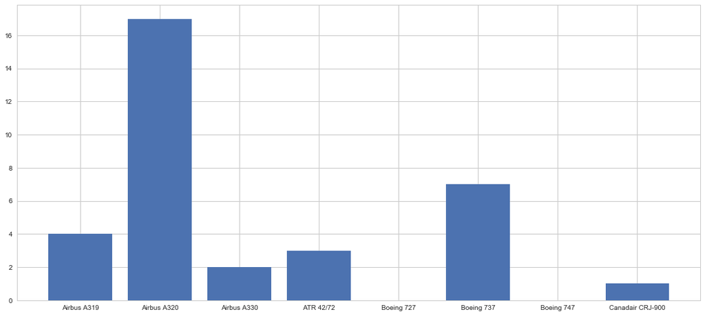

```python
num=pd.to_numeric(liste2.Current)
fig = plt.figure(figsize=(18,8))
plt.bar(liste2.AircraftType,num)
```

Tunis air dispose en moyenne de 34 avions

## Egypte Air

```
<BarContainer object of 18 artists>
```

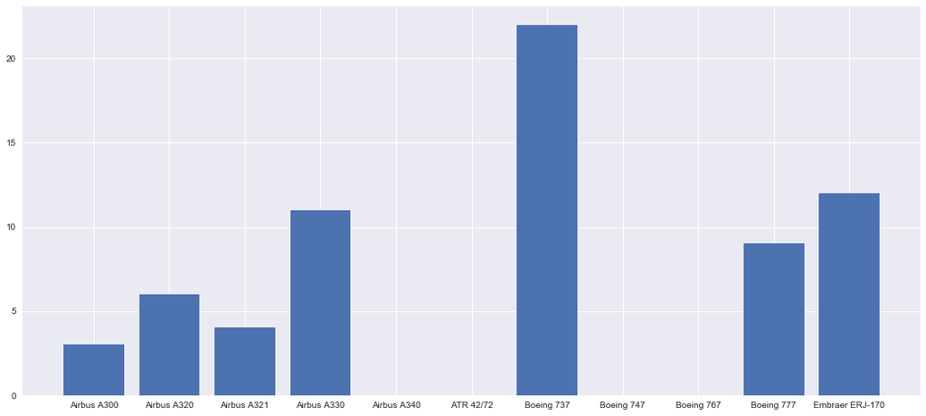

```python
numEgypt=pd.to_numeric(liste2Egypte.Current)
fig = plt.figure(figsize=(18,8))
plt.bar(liste2Egypte.AircraftType,numEgypt)
```

Egypte Air dispose de 73 avions

## China Esatern Airlines

```
<BarContainer object of 34 artists>
```

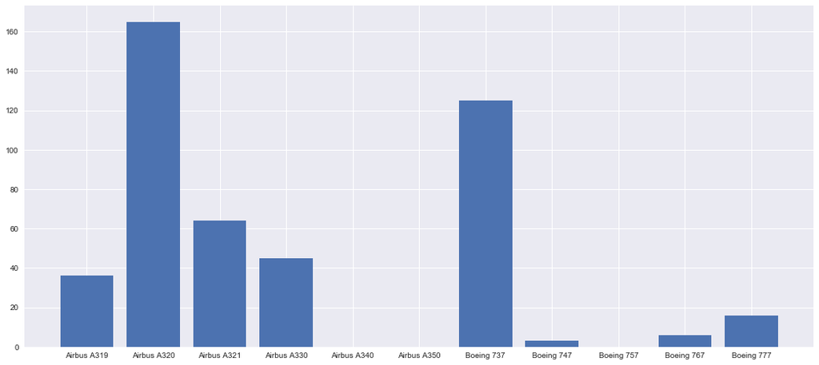

```python
numChinaEastern=pd.to_numeric(liste2ChineEastern.Current)
fig = plt.figure(figsize=(18,8))
plt.bar(liste2ChineEastern.AircraftType,numChinaEastern)
```

China Eastern Airlines dipose de 579 avions

## Royal Air Maroc

```
<BarContainer object of 11 artists>
```

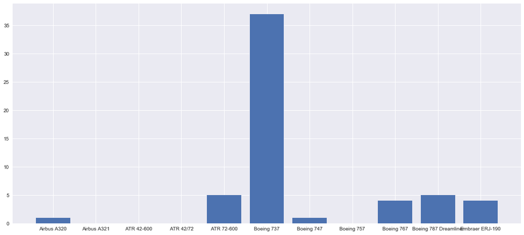

```python
numRoyalMaroc=pd.to_numeric(liste2RoyalMaroc.Current)
fig = plt.figure(figsize=(18,8))
plt.bar(liste2RoyalMaroc.AircraftType,numRoyalMaroc)
```

Royal Air Maroc dispose de 57 avions

## Air Algerie

```
56.0
```

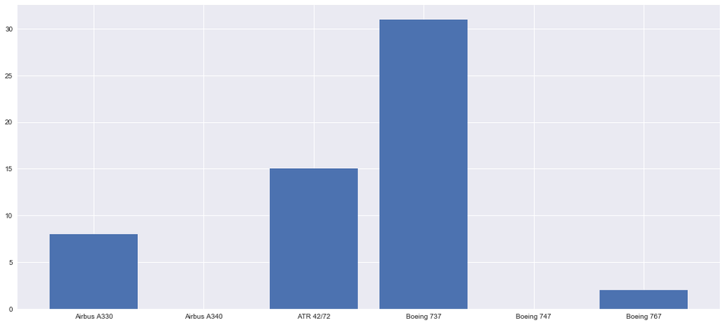

```python
numAirAlgerie=pd.to_numeric(liste2AireAlgerie.Current)
fig = plt.figure(figsize=(18,8))
plt.bar(liste2AireAlgerie.AircraftType,numAirAlgerie)
np.sum(numAirAlgerie)
```

Air Algerie dispose de 56 avions

## Conclusion :

En terme de nombre d'avions Tunis Air est derrière les flottes des pays voisins et les concurrents directes comme Air Algerie ou Royal Air Maroc , cependant elle est très loin d'avoir un nombre d'avions aussi important que celui de China Eastern Airlines dont le nombre d'avions représente 17 fois le nombre d'avions de Tunis Air.

### 2.2- Etude comparative des flottes basée sur le critère de l'age :

## Moyenne d'age des avions de toutes les flottes

```python
tunisair=data.loc[data['Airline'] == "Tunisair"]
maroc=data.loc[data['Airline'] == "Royal Air Maroc"]
algerie=data.loc[data['Airline'] == "Air Algerie"]
china=data.loc[data['Airline'] == "China Eastern Airlines"]
egypt=data.loc[data['Airline'] == "EgyptAir"]
```

```
The average age: 10.115000000000004
```

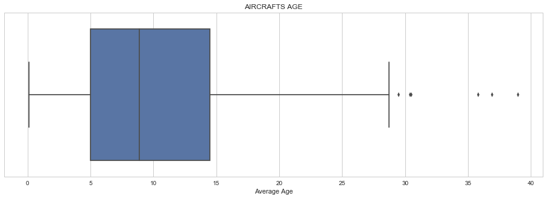

```python
fig = plt.figure(figsize=(16,5))
sns.set_style("whitegrid")
ax = sns.boxplot(x=data["Average Age"]).set_title('AIRCRAFTS AGE')
print("The average age:",data["Average Age"].mean())
```

## Tunis Air

```
La moyenne d age des avions :  12.366666666666665
```

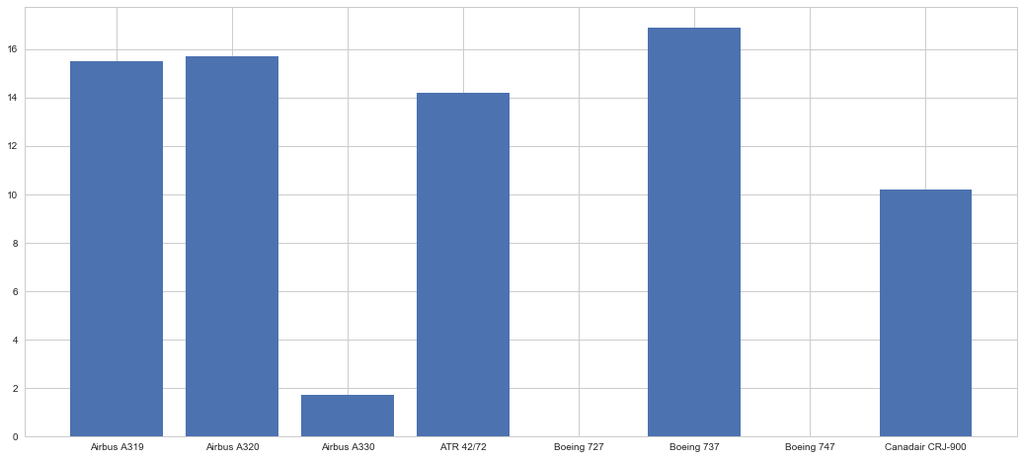

```python
num1=pd.to_numeric(liste2.Age)
fig = plt.figure(figsize=(18,8))
plt.bar(liste2.AircraftType,num1)
print("La moyenne d age des avions : ",np.mean(num1))
```

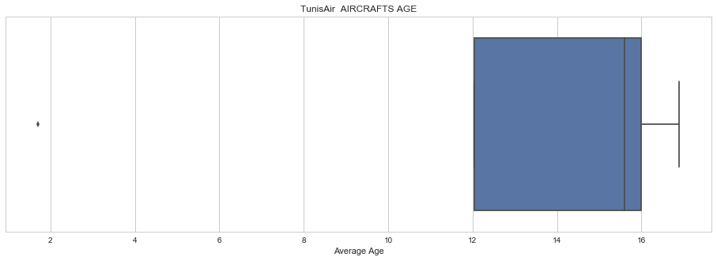

```python
fig = plt.figure(figsize=(16,5))
sns.set_style("whitegrid")
ax = sns.boxplot(x=tunisair["Average Age"]).set_title('TunisAir  AIRCRAFTS AGE')
```

## Egypte Air

```
La moyenne d age des avions :  13.725000000000001
```

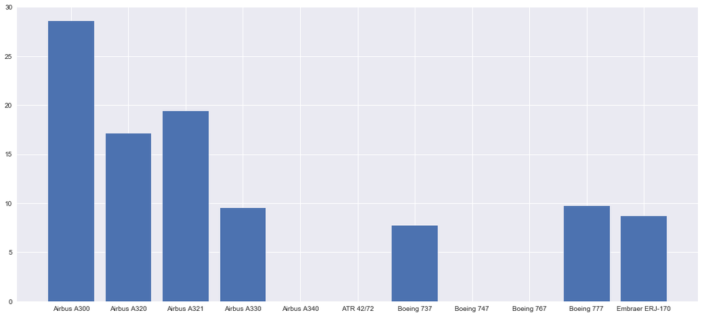

```python
num1Egypt=pd.to_numeric(liste2Egypte.Age)
fig = plt.figure(figsize=(18,8))
plt.bar(liste2Egypte.AircraftType,num1Egypt)
print("La moyenne d age des avions : ",np.mean(num1Egypt))
```

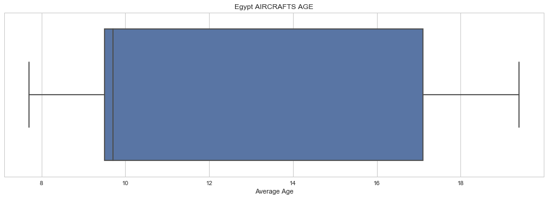

```python
fig = plt.figure(figsize=(16,5))
sns.set_style("whitegrid")
ax = sns.boxplot(x=egypt["Average Age"]).set_title('Egypt AIRCRAFTS AGE')
```

## Royal Air Maroc

```
La moyenne d age des avions :  10.442857142857141
```

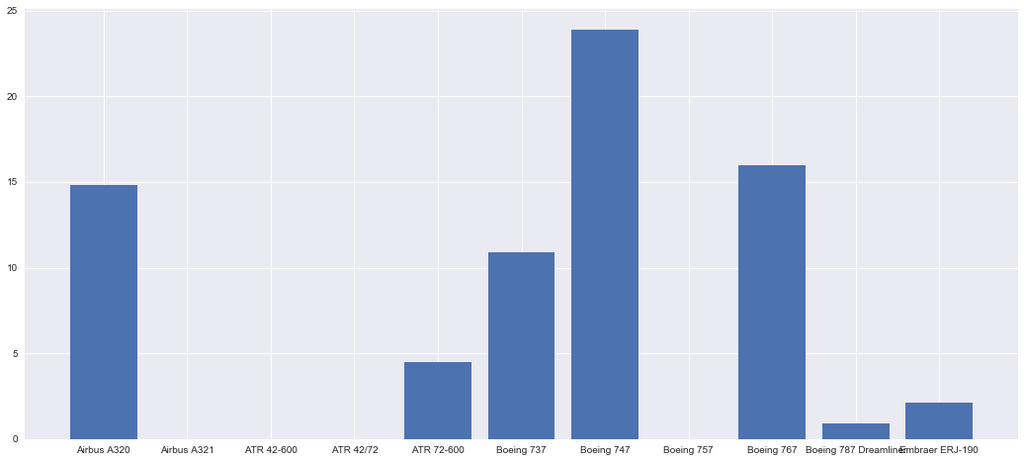

```python
num1RoyalMaroc=pd.to_numeric(liste2RoyalMaroc.Age)
fig = plt.figure(figsize=(18,8))
plt.bar(liste2RoyalMaroc.AircraftType,num1RoyalMaroc)
print("La moyenne d age des avions : ",np.mean(num1RoyalMaroc))
```

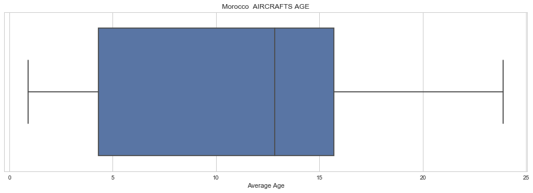

```python
fig = plt.figure(figsize=(16,5))
sns.set_style("whitegrid")
ax = sns.boxplot(x=maroc["Average Age"]).set_title('Morocco  AIRCRAFTS AGE')
```

## Air Algerie

```
La moyenne d age des avions :  13.350000000000001
```

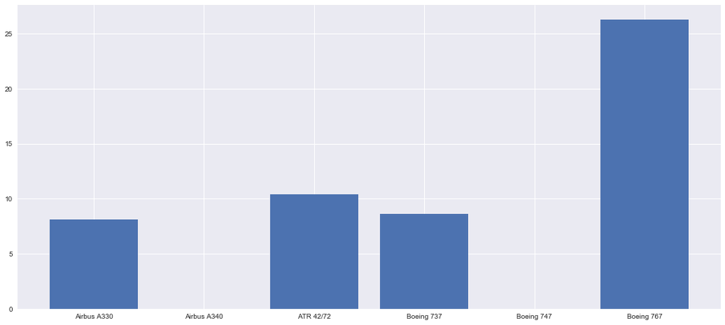

```python
num1AireAlgerie=pd.to_numeric(liste2AireAlgerie.Age)
fig = plt.figure(figsize=(18,8))
plt.bar(liste2AireAlgerie.AircraftType,num1AireAlgerie)
print("La moyenne d age des avions : ",np.mean(num1AireAlgerie))
```

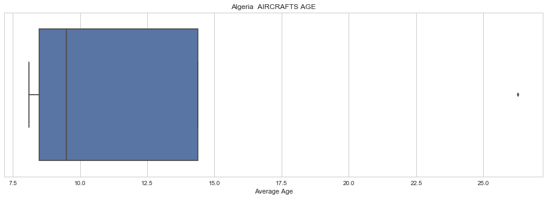

```python
fig = plt.figure(figsize=(16,5))
sns.set_style("whitegrid")
ax = sns.boxplot(x=algerie["Average Age"]).set_title('Algeria  AIRCRAFTS AGE')
```

## China Eastern Airlines

```
La moyenne d age des avions :  6.608333333333333
```

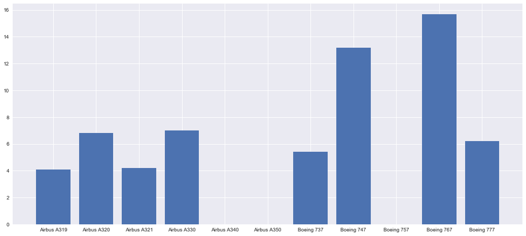

```python
num1ChinaEastern=pd.to_numeric(liste2ChineEastern.Age)
fig = plt.figure(figsize=(18,8))
plt.bar(liste2ChineEastern.AircraftType,num1ChinaEastern)
print("La moyenne d age des avions : ",np.mean(num1ChinaEastern))
```

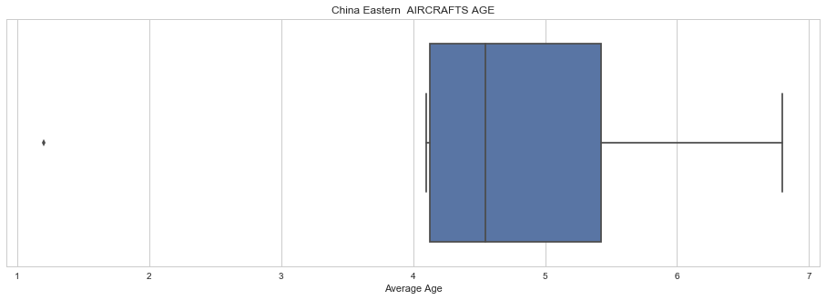

```python
fig = plt.figure(figsize=(16,5))
sns.set_style("whitegrid")
ax = sns.boxplot(x=china["Average Age"]).set_title('China Eastern  AIRCRAFTS AGE')
```

## Conclusion

L'age moyen international des avions est de 10 ans. Tunis Air a un age moyen de 12 ans qui est bien comparé à ces concurrents mais qui est plus grand que l'age moyen international et beacoup plus grand que celui de china Eastern qui est de 6 ans. Cependant si on regarde de plus près tous les avions de la flotte Tunisienne ont au moins plus de 10 ans sauf pour le modèle Airbus 330 qui n'a que 2 ans .

### 2.3- Etude comparative basée sur le critère Prix unitaire

## Tunis Air

```python
tp=tunisair["Unit Cost"]
j=[]
for i in tp:

    j.append(i.replace(i[0],""))

tunisair["Unit Cost"]=j
```

[output not shown]

```
Le prix unitaire moyen: 106.18181818181819
```

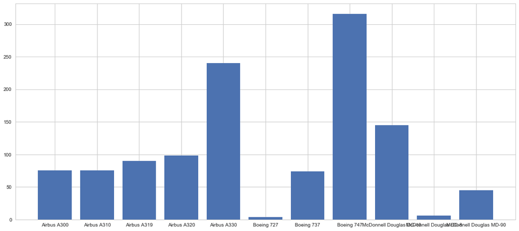

```python
fig = plt.figure(figsize=(18,8))
plt.bar(tunisair["Aircraft Type"],height=pd.to_numeric(tunisair["Unit Cost"]))
print("Le prix unitaire moyen:",pd.to_numeric(tunisair["Unit Cost"]).mean())
```

## Egypte Air

```python
ep=egypt["Unit Cost"]
j=[]
for i in ep:

    j.append(i.replace(i[0],""))

egypt["Unit Cost"]=j
```

[output not shown]

```
Le prix unitaire moyen: 140.75
```

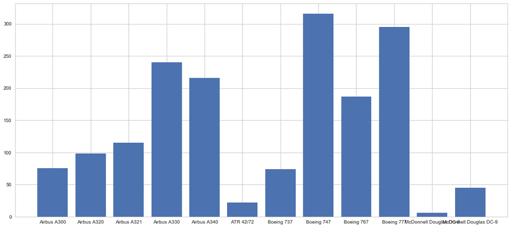

```python
fig = plt.figure(figsize=(18,8))
plt.bar(egypt["Aircraft Type"],height=pd.to_numeric(egypt["Unit Cost"]))
print("Le prix unitaire moyen:",pd.to_numeric(egypt["Unit Cost"]).mean())
```

## Royal Maroc Airlines

```python
mp=maroc["Unit Cost"]
j1=[]
for i in mp:

    j1.append(i.replace(i[0],""))

maroc["Unit Cost"]=j1
```

[output not shown]

```
Le prix unitaire moyen: 132.88888888888889
```

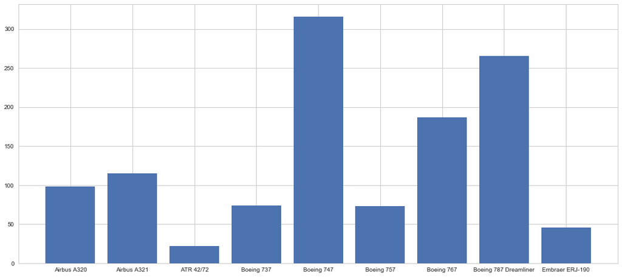

```python
fig = plt.figure(figsize=(18,8))
plt.bar(maroc["Aircraft Type"],height=pd.to_numeric(maroc["Unit Cost"]))
print("Le prix unitaire moyen:",pd.to_numeric(maroc["Unit Cost"]).mean())
```

## Air Algerie

```python
ap=algerie["Unit Cost"]
j2=[]
for i in ap:

    j2.append(i.replace(i[0],""))

algerie["Unit Cost"]=j2
```

[output not shown]

```
Le prix unitaire moyen: 154.92307692307693
```

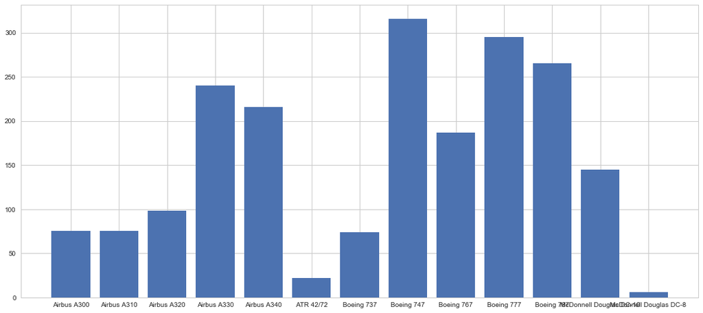

```python
fig = plt.figure(figsize=(18,8))
plt.bar(algerie["Aircraft Type"],height=pd.to_numeric(algerie["Unit Cost"]))
print("Le prix unitaire moyen:",pd.to_numeric(algerie["Unit Cost"]).mean())
```

## China Eastern Airlines

```python
cp=china["Unit Cost"]
j=[]
for i in cp:

    j.append(i.replace(i[0],""))

china["Unit Cost"]=j
```

[output not shown]

```
Le prix unitaire moyen: 123.05
```

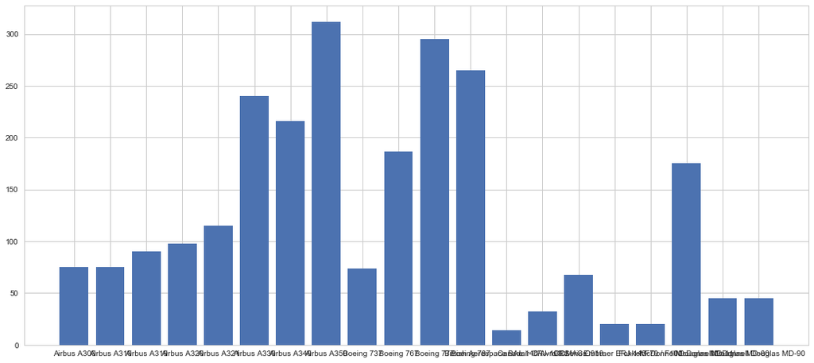

```python
fig = plt.figure(figsize=(18,8))
plt.bar(china["Aircraft Type"],height=pd.to_numeric(china["Unit Cost"]))
print("Le prix unitaire moyen:",pd.to_numeric(china["Unit Cost"]).mean())
```